[OHI-Northeast](http://www.ohi-northeast.org/) | [OHI Science](http://ohi-science.org) | [Citation policy](http://ohi-science.org/citation-policy/)

# OHI-Northeast: Eelgrass habitat layer

Compiled on Mon Jun 15 11:48:37 2020 by afflerbach

# Summary

This script creates the Eelgrass habitat data layer for the Habitats goal (a sub-goal of Biodiversity).

There is not great eelgrass data available for the region. We identify all locations where eelgrass beds have been recorded since the 1980’s and use the Water Quality Index data from all water quality monitoring sites within 10km of the beds. We also add in the sites from Long Island Sound.

# Data Source(s)

#### Water Quality Data

**Reference**: Environmental Protection Agency (EPA) [National Coastal Condition Assessment (NCCA) Data](https://www.epa.gov/national-aquatic-resource-surveys/ncca)

**Downloaded**: July 31, 2018

**Description**: Measurements and status of water quality indicators at multiple sites across the Northeast region.

**Time range**: 2005-2006, 2010

**Format**: Tabular (.csv)

#### Eelgrass beds

**Reference**: [Northeast Ocean Data Portal](https://www.northeastoceandata.org/data-explorer/?habitat%7Cbiological)

**Downloaded**: May 9, 2019

**Description**: Locations of current and historical eelgrass beds in the Northeast.

**Time range**: Earliest year is 1981 - current. Although availability by state is sporadic.

**Format**: Geodatabase and shapefiles

# Setup

```r
knitr::opts_chunk$set(fig.width = 6, fig.height = 4, fig.path = 'figs/',
                      echo = TRUE, message = FALSE, warning = FALSE)

source('~/github/ne-prep/src/R/common.R')

library(magrittr)
library(sf)
library(leaflet)
library(mapview)
library(htmlwidgets)
```

# Data cleaning

## Load eelgrass spatial data

The shapefiles were cleaned and saved in the `eelgrass.Rmd` script.

```r
current <- read_sf(file.path(dir_anx, "hab/current_eelgrass_locations/current_eelgrass_locations.shp"))  %>% st_make_valid() #make the geometry valid
past    <- read_sf(file.path(dir_anx, "hab/past_eelgrass_locations/past_eelgrass_locations.shp")) %>% st_make_valid() #make the geometry valid
gbe     <- read_sf(file.path(dir_anx, "hab/gbe_eelgrass_locations/gbe_eelgrass_locations.shp")) %>% st_make_valid() #make the geometry valid
lines   <- read_sf(file.path(dir_anx, "hab/line_eelgrass_locations/line_eelgrass_locations.shp"))
```

## Load & spatialize NCCA data

First get the site info data. This data lists all site IDs, lat, long, and site weights which we use in the analysis.

```r
#load site info for 05/06 time period
site_info_1 <- readxl::read_excel(file.path(dir_anx, "_raw_data/EPA/nca_siteinformationdata_narschallenge.xlsx")) %>%
  filter(PSTL_CODE %in% c("MA", "ME", "RI", "NY", "NH", "CT"),
         SAMPYEAR > 2001) %>%
  select(SITE_ID, PSTL_CODE, LON_DD, LAT_DD, WGT_NCA_56)

#load site info for 2010 time period
site_info_2 <- read_csv(file.path(dir_anx, "_raw_data/EPA/assessed_ncca2010_siteinfo.revised.06212016.csv")) %>%
  filter(STATE %in% c("MA", "ME", "RI", "NY", "NH", "CT"),
         NCA_REGION == "East Coast")  %>%
  select(SITE_ID, STATE, LON_DD = ALON_DD, LAT_DD = ALAT_DD, WGT_NCCA10)
```

Use the `sf` package to turn the data into shapefile using the longitude/latitude

```r
#spatialize sites from 05/06 dataset
site_1 <- site_info_1 %>%
  select(SITE_ID, LON_DD, LAT_DD, STATE = PSTL_CODE) %>%
  distinct() %>%
  st_as_sf(coords = c("LON_DD", "LAT_DD"), crs = 4326) %>%
  st_transform(crs = st_crs(current))

#spatialize sites from 2010 dataset
site_2 <- site_info_2 %>%
  select(SITE_ID, STATE, LAT_DD, LON_DD) %>%
  distinct() %>%
  st_as_sf(coords = c("LON_DD", "LAT_DD"), crs = 4326) %>%
  st_transform(crs = st_crs(current))

#combine
sites <- rbind(site_1, site_2)
```

There are a total of 453 water quality monitoring sites.

Create an interactive .html map to look at alignment of sites and beds.

```r
#map the data layers
interactive_map <-  mapview(past, col.regions = "darkred", layer.name = "Past eelgrass locations") +
  mapview(gbe, col.regions = "darkorange", layer.name = "Great Bay Estuary") +
  mapview(current, col.regions = "darkgreen", layer.name = "Current eelgrass locations") +
  mapview(sites, layer.name = "Monitoring sites")

## save interactive map
#mapshot(interactive_map, url = "eelgrass_map.html")
```

## Intersect eelgrass beds and NCCA sites

We are going to overlap the sites with the eelgrass polygons and identify those sites that intersect. We want to use a 10 km buffer to expand the intersection area of the points.

Get the buffer

```r
sites_w_buffer <- st_buffer(sites, 10000)
```

Intersect eelgrass beds and monitoring sites

```r
#intersect
current_sites <- st_intersection(sites_w_buffer, current)
past_sites    <- st_intersection(sites_w_buffer, past)
gbe_sites     <- st_intersection(sites_w_buffer, gbe)
lines_sites   <- st_intersection(sites_w_buffer, lines) #gives us nothing

#combine
eelgrass_sites_int <- rbind(current_sites, past_sites, gbe_sites, lines_sites)

eelgrass_sites <- filter(sites, SITE_ID %in% eelgrass_sites_int$SITE_ID)
```

## Identify Long Island Sound sites

We also want to include the water quality monitoring sites in Long Island Sound (LIS). Our buffer approach still misses these sites since there are no eelgrass beds mapped from this region. But we know that historically eelgrass beds were present in LIS.

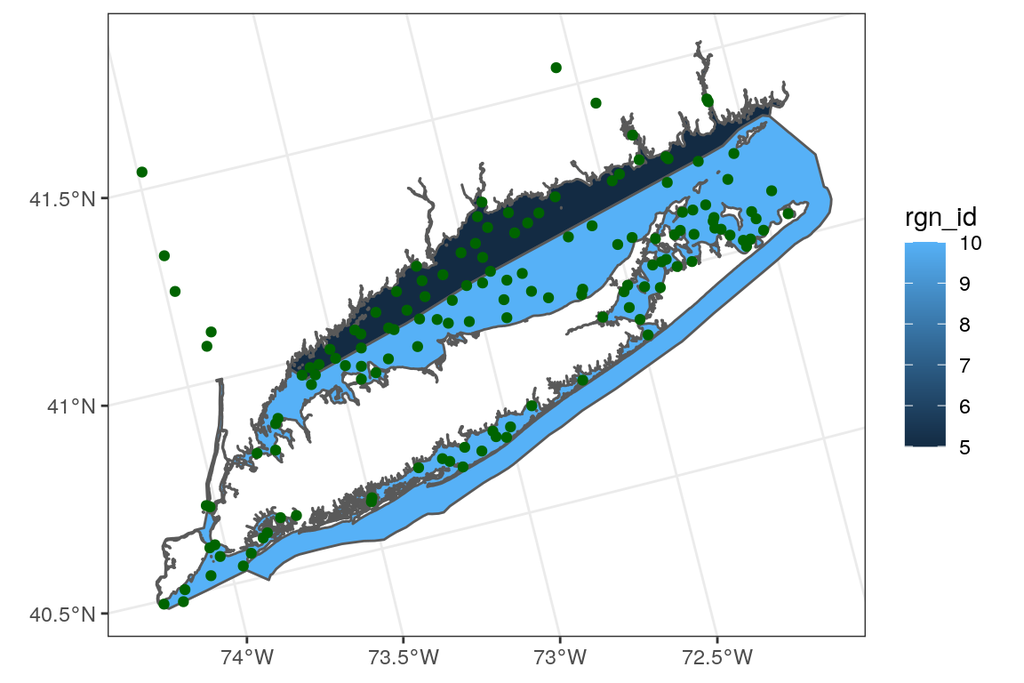

```r
#filter wqi for sites only in MA
lis <- sites %>%
  filter(STATE %in% c("NY","CT"))

#create a simple features (sf) object from the coordinates contained in the dataset
lis_points = st_as_sf(lis, coords = c("LON_DD", "LAT_DD"),
                 crs = 4326)
#plot
ggplot() +
  geom_sf(data = rgns %>% filter(rgn_id %in% c(5,10)), aes(fill = rgn_id)) +
  geom_sf(data = lis_points, color = 'darkgreen') +
  theme_bw()
```

```r
#get points that intersect with both NY and CT regions
ct_ny_points <- st_intersection(lis_points, rgns %>% filter(rgn_id %in% c(10, 5))) %>%
  select(SITE_ID, STATE)
```

## Get site specific NCCA data

Now that we have our 419 sites we can grab the NCCA WQI status data for these sites.

```r
#load WQI data for 05/06
water_old <- readxl::read_excel(file.path(dir_anx, "_raw_data/EPA/nca_waterchemdata_narschallenge.xlsx")) %>%
  filter(PSTL_CODE %in% c("MA", "ME", "RI", "NY", "NH", "CT"),
         SITE_ID %in% eelgrass_sites$SITE_ID | SITE_ID %in% ct_ny_points$SITE_ID) %>%
  select(SITE_ID, status = Cat_WQI, LON_DD, LAT_DD, PSTL_CODE, Year = SAMPYEAR) %>%
  left_join(site_info_1) #this adds in the site weights

#load WQI data for 2010
water_new <- read_csv(file.path(dir_anx, "_raw_data/EPA/ncca2010_water_quality_indicator_status.csv")) %>%
  filter(PSTL_CODE %in% c("MA", "ME", "RI", "NY", "NH", "CT"),
         NCCA_REG == "Northeast",
         SITE_ID %in% eelgrass_sites$SITE_ID | SITE_ID %in% ct_ny_points$SITE_ID) %>%
  select(SITE_ID, status = CAT_WQI, LON_DD, LAT_DD, PSTL_CODE) %>%
  mutate(Year = 2010) %>%
  left_join(site_info_2, by = "SITE_ID") %>% #have to join just by SITE_ID. When joining with LAT and LON the WGTs dont show... it's weird
  select(SITE_ID, status, LON_DD = LON_DD.x, LAT_DD = LAT_DD.x, PSTL_CODE, Year, STATE, WGT_NCCA10)
```

Combining both datasets and assigning the time periods for each. If the year is 2005-2006, time period is 1 and 2010 is time period 2.

```r
wqi <- water_old %>%
  bind_rows(water_new) %>%
  mutate(time_period =
           case_when(
             Year %in% c(2005, 2006) ~ 1,
             Year == 2010 ~ 2
           ))
```

## Massachusetts Sites

Now assign OHI region names or ids to each of the sites. For the most part, the State in the WQI data is the region, but for Massachusetts we need to be specific about what region the sites belong to. The best way to do this is manually so I use `mapview::mapview()` to identify sites in MA and assign to either Massachusetts-North or Massachusetts-South.

Look first just at sites identified by the `MA` postal code.

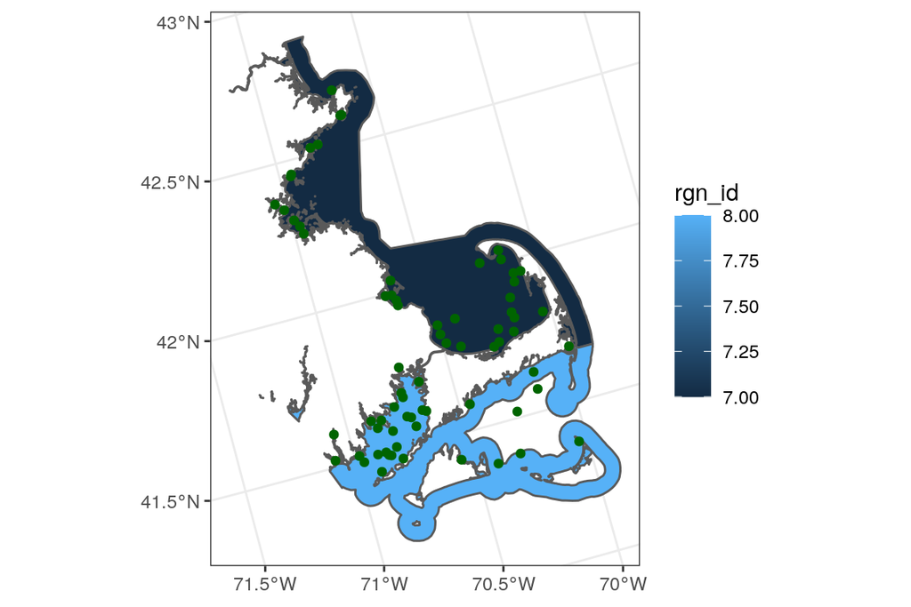

```r
#filter wqi for sites only in MA
ma <- wqi %>%
  filter(PSTL_CODE == "MA")

#create a simple features (sf) object from the coordinates contained in the dataset
ma_points = st_as_sf(ma, coords = c("LON_DD", "LAT_DD"),
                 crs = 4326)
#plot
ggplot() +
  geom_sf(data = rgns %>% filter(rgn_id %in% c(7,8)), aes(fill = rgn_id)) +
  geom_sf(data = ma_points, color = 'darkgreen') +
  theme_bw()
```

```r
int <- ma_points %>%
  st_transform(crs = st_crs(rgns)) %>%
  st_intersection(rgns)


#find sites that are not in the intersection
s <- setdiff(ma_points$SITE_ID, int$SITE_ID)

#limit to just the missing sites
miss <- ma_points %>%
  filter(SITE_ID %in% s)

miss_gf <- miss %>%
  data.frame() %>%
  mutate(rgn_id =
           case_when(
             SITE_ID == "NCCA10-1008" ~ 8,
             SITE_ID == "NCCA10-1001" ~ 8
           )) %>%
  select(-geometry)
```

Take the info from `int` that we want and combine with these missing sites

```r
ma_df <- int %>%
  data.frame() %>%
  select(-area_km2, -geometry, -rgn_name) %>%
  bind_rows(miss_gf)
```

## Combine all data

Additional data cleaning that adds the Massachusetts & Long Island Sound sites back in

```r
wqi_clean <- wqi %>%
  select(SITE_ID, status, PSTL_CODE, Year, time_period, LON_DD, LAT_DD, WGT_NCA_56, WGT_NCCA10) %>%
  mutate(rgn_name =
           case_when(
             PSTL_CODE == "ME" ~ "Maine",
             PSTL_CODE == "RI" ~ "Rhode Island",
             PSTL_CODE == "NY" ~ "New York",
             PSTL_CODE == "CT" ~ "Connecticut",
             PSTL_CODE == "NH" ~ "New Hampshire",
             PSTL_CODE == "MA" ~ "NA"
           )) %>%
  left_join(rgn_data) %>%
  left_join(ma_df, by = c("SITE_ID", "time_period", "Year", "status", "PSTL_CODE")) %>%
  mutate(rgn_id = ifelse(is.na(rgn_id.x), rgn_id.y, rgn_id.x)) %>%
  select(SITE_ID, status, PSTL_CODE, Year, time_period, LON_DD, LAT_DD, WGT_NCA_56.x, WGT_NCCA10.x, state, rgn_id) %>%
  left_join(rgn_data, by = "rgn_id") %>%
  select(-area_km2, -state.x, -state.y) %>%
  rename(WGT_NCA_56 = WGT_NCA_56.x,
         WGT_NCCA10 = WGT_NCCA10.x) %>%
  filter(Year > 2004) %>% #remove the early years
  as.data.frame()
```

Let’s see how the status of each of our indicators is for these sites

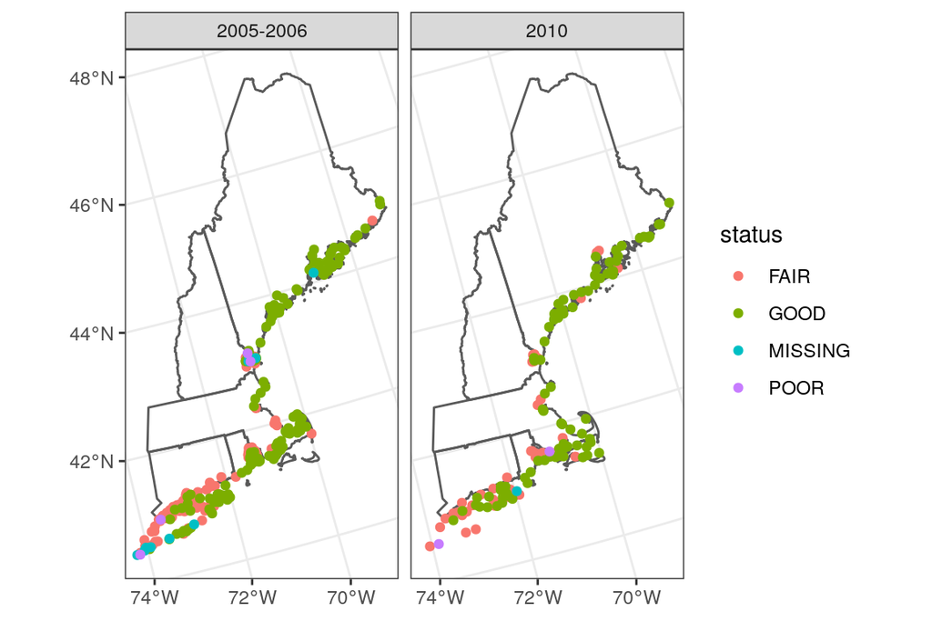

```r
site_status <- sites %>%
  inner_join(wqi_clean, by = c("SITE_ID")) %>%
  mutate(year = case_when(
    time_period == 1 ~ "2005-2006",
    time_period == 2 ~ "2010"
  ))

#map
ggplot() +
  geom_sf(data = ne_states %>% filter(!STUSPS %in% c("PA", "VT", "NJ", "NY")), fill = NA) +
  geom_sf(data = site_status, aes(color = status, fill = status)) +
  facet_wrap(~year) +
  theme_bw()
```

# Analysis

## Get scores using `spsurvey`

Use the [`spsurvey`](https://www.rdocumentation.org/packages/spsurvey/versions/3.4) package to run `cat.analysis` and produce a sub-population estimate that incorporates site weights.

We remove all sites that have `MISSING` as a status. In this data, New York has 5%, New Hampshire has 3.5% and Maine has 2% missing.

In 2010 only New York has missing sites, a total of 3.35% of area.

**For now I will ignore the MISSING sites**

```r
library(spsurvey)
```

```r
#select just 0506 data
wqi_0506 <- wqi_clean %>%
  rename(siteID = SITE_ID) %>%
  filter(Year < 2007, status != "MISSING")

# Create the required data frames
sites <- wqi_0506 %>%
          select(siteID) %>%
          mutate(use = rep(TRUE, nrow(.)))
#create the subpopulation dataset. we need to add region 12 (the whole northeast) as well
subpop1 <- wqi_0506 %>%
          select(siteID, rgn_name)
subpop2 <- wqi_0506 %>%
          select(siteID) %>%
          mutate(rgn_name = "Northeast")
design <- wqi_0506 %>%
          select(siteID,
                 wgt = WGT_NCA_56,
                 xcoord = LON_DD,
                 ycoord = LAT_DD)
data <- wqi_0506 %>%
        select(siteID, status)

## from this output we only want to grab. Estimate.P is the percent of area (e.g. 98%) for the coastal waters of a subpopulation (e.g. Maine) in a particular category of condition (e.g. Good)
Water_Column_Status_Estimates_0506_1 <- cat.analysis(sites, subpop1, design, data) #individual regions (state level sites)
Water_Column_Status_Estimates_0506_2 <- cat.analysis(sites, subpop2, design, data) #all sites

Water_Column_Status_Estimates_0506 <- bind_rows(Water_Column_Status_Estimates_0506_1, Water_Column_Status_Estimates_0506_2) %>%
  select(rgn_name = Subpopulation, Category, perc = Estimate.P) %>%
  mutate(cat_score =
      case_when(
        Category == "POOR" ~ 0,
        Category == "FAIR" ~ 50,
        Category == "GOOD" ~ 100
      ),
      year = 2006)
```

Do the same `cat.analysis` but for 2010 data.

```r
# Create the required data frames
wqi_2010 <- wqi_clean %>%
  filter(Year == 2010, status != "MISSING") %>%
  rename(siteID = SITE_ID)

sites <- wqi_2010 %>%
          select(siteID) %>%
          mutate(use = rep(TRUE, nrow(.)))
#create the subpopulation dataset. we need to add region 12 (the whole northeast) as well
subpop1 <- wqi_2010 %>%
          select(siteID, rgn_name)
subpop2 <- wqi_2010 %>%
          select(siteID) %>%
          mutate(rgn_name = "Northeast")
design <- wqi_2010 %>%
          select(siteID,
                 wgt = WGT_NCCA10,
                 xcoord = LON_DD,
                 ycoord = LAT_DD)
data <- wqi_2010 %>%
        select(siteID, status)

## from this output we only want to grab. Estimate.P is the percent of area (e.g. 98%) for the coastal waters of a subpopulation (e.g. Maine) in a particular category of condition (e.g. Good)
Water_Column_Status_Estimates_2010_1 <- cat.analysis(sites, subpop1, design, data)
```

```
## During execution of the program, 2 warning messages were generated.  The warning
## messages are stored in a data frame named 'warn.df'.  Enter the following
## command to view the warning messages: warnprnt()
## To view a subset of the warning messages (say, messages number 1, 3, and 5),
## enter the following command: warnprnt(m=c(1,3,5))
```

```r
Water_Column_Status_Estimates_2010_2 <- cat.analysis(sites, subpop2, design, data)

Water_Column_Status_Estimates_2010 <- bind_rows(Water_Column_Status_Estimates_2010_1, Water_Column_Status_Estimates_2010_2) %>%
  select(rgn_name = Subpopulation, Category, perc = Estimate.P) %>%
  mutate(cat_score =
      case_when(
        Category == "POOR" ~ 0,
        Category == "FAIR" ~ 50,
        Category == "GOOD" ~ 100
      ),
      year = 2010)
```

# Calculate eelgrass data layer

Aggregate by region and get WQI scores

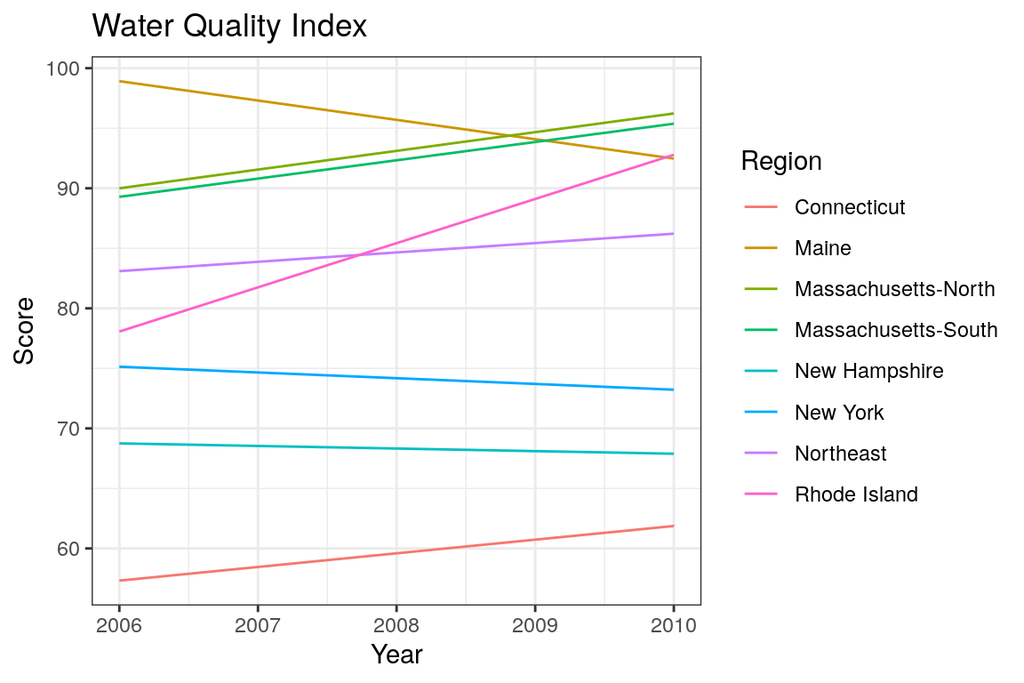

```r
wqi_rgns <- Water_Column_Status_Estimates_0506 %>%
  rbind(Water_Column_Status_Estimates_2010) %>%
  mutate(score = cat_score * (perc/100)) %>%
  filter(Category != "Total",
         rgn_name != "Georges Bank") %>%
  group_by(rgn_name, year) %>%
  summarize(wqi_score = sum(score)) %>%
  ungroup()

write_csv(wqi_rgns, "data/eelgrass_score_rgns.csv")

ggplot(wqi_rgns, aes(x = year, y = wqi_score, color = rgn_name)) +
  geom_line() +
  theme_bw() +
  labs(x = "Year",
       y = "Score",
       color = "Region",
       title = "Water Quality Index")
```

## Gap-filling

The plot has guessed the values between 2006 and 2010 but we need to actually assign these before saving this layer. We will assume a simple linear interpolation between years.

```r
df_gf <- wqi_rgns %>%
  group_by(rgn_name) %>%
  complete(year = 2006:2010) %>%
  mutate(score = zoo::na.approx(wqi_score)) %>%
  complete(year = 2006:2017) %>%
  ungroup() %>%
  filter(rgn_name != "Georges Bank") %>% # no idea why this is showing up after the second complete!
  mutate(score = zoo::na.locf(score), #now we carry forward the 2010 value for all years to 2017
         gapfilled = ifelse(is.na(wqi_score), 1, 0))

write_csv(df_gf, "data/eelgrass_score_rgn_gf.csv")
```

## Save layer for toolbox

I need to attach region ID’s to each row. I also add the offshore regions 1:4 with NA values for the toolbox to run.

```r
other_rgns <- data.frame(year     = rep(2006:2017, each = 4),
                         rgn_id   = c(1,2,3,4),
                         rgn_name = c("Offshore", "Georges Bank", "Gulf of Maine", "Mid-Atlantic Bight"),
                         score = NA)

out <- df_gf %>%
  left_join(rgn_data) %>%
  select(year, rgn_id, rgn_name, score) %>%
  filter(rgn_name != "Georges Bank") %>% #remove the Georges bank
  bind_rows(other_rgns) %>%
  mutate(rgn_id = ifelse(rgn_name == "Northeast", 12, rgn_id)) %>%
  mutate(habitat = "eelgrass")


#save
write_csv(out, file.path(dir_calc, "layers/hab_eelgrass.csv"))
```